# Deep Dive #8 - Integrating Factor Method

Remember, matricies aren't actually scary. They just say that the rate of change of a variable is dependent on the current value of other variables.

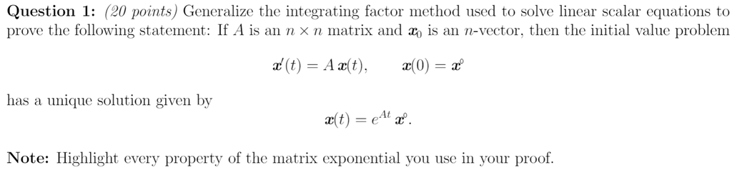

The integrating factor method introduced in section 1.4 for constant coefficients is $y'=ay \implies y= ce^{at}$ which, with intial value $y_0=y(0)$ this becomes $y=y_0e^{at}$

How do we do this when A is a matrix? We'll use the property of matrix exponentials $\left(e^{At}\right)'=e^{At}A $ as follows

$$ x'=Ax \\ x'-Ax={0} \\ e^{-At}x'-e^{-At}Ax=e^{-At}{0}\\ e^{-At}x'+e^{-At}(-A)x={0}\\ e^{-At}x'+\left(e^{-At}\right)'x={0}\\ \left(e^{-At}x\right)'={0} \\ e^{-At}x={c} \\ x(t)=e^{At}c \\ x(0)=e^0c=x^0\implies c=x^0\\ x(t)=e^{At}x^0 $$

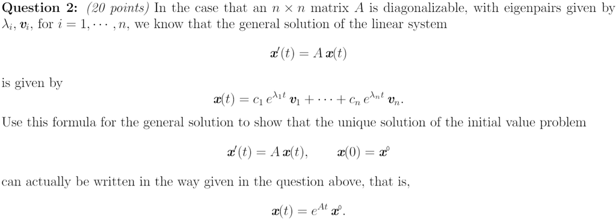

Show $x(t)=c_1e^{\lambda_1t}v_1+\cdots+c_ne^{\lambda_nt}v_n=e^{At}x^0$

Note that $x(0)=x^0=c_1v_1+\cdot+c_nv_n$. Thus we have

$$ e^{At}x^0=e^{At}\left(c_1v_1+\cdot+c_nv_n\right)\\=e^{At}c_1v_1+\cdots+e^{At}c_nv_n=c_1e^{At}v_1+\cdots+c_ne^{At}v_n $$

In deep dive #7 Question 6 we showed that $e^{A}v=e^{\lambda}v$. I'll copy-and-paste the proof in here, now with the addition of $t$.

Each $\lambda$ and $v$ correspond to a pair of $\lambda_i$ and $v_i$. $$ e^{At} v = Iv + Atv + \frac{A^2t^2v}{2}+\dots+\frac{A^nt^nv}{n!} \\ =Iv + Avt + \frac{A^2vt^2}{2}+\dots+\frac{A^nvt^n}{n!} = Ivt + \lambda vt + \frac{\lambda^2vt^2}{2}+\dots+\frac{\lambda^nvt^n}{n!}\\ = Itv + \lambda tv + \frac{\lambda^2t^2v}{2}+\dots+\frac{\lambda^nt^nv}{n!} \\ =e^{\lambda t} v $$

Returning to question 2, this gives us $$ c_1e^{At}v_1+\cdots+c_ne^{At}v_n=c_1e^{\lambda_1t}v_1+\cdots+c_ne^{\lambda_nt}v_n=x(t) $$

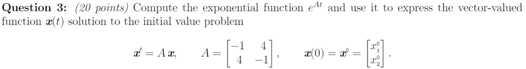

Compute the exponential function $e^{At}$? Doesn't that have like, infinite terms?

$$ e^{At}=\sum_{k=0}^\infty \frac{A^kt^k}{k!}=\begin{pmatrix} e^{-t} & e^{4t} \\ e^{4t} & e^{-t} \end{pmatrix}\\ $$

As such $x(t)=e^{At}x^0$

$$ x(t)=\begin{pmatrix} x_1^0 e^{-t} +x_2^0e^{4t} \\ x_1^0 e^{4t}+ x_2^0e^{-t} \end{pmatrix} $$

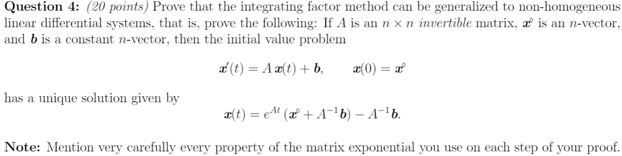

That looks like slightly more work than question 1.

We'll start by following our solution to question 1.

$$ x'-Ax={ b} \\ e^{-At}x'-e^{-At}Ax=e^{-At}{ b} \\ \left(e^{-At}x \right)'= e^{-At}{ b} $$

Can we go and integrate $e^{-At}{ b}$? Since $\left(e^{-At}\right)'=-A e^{-At}$ and ${ b}$ is constant, we have $$\left(-A^{-1}e^{-At} { b}\right)'=A^{-1}Ae^{-At}{ b} = e^{-At}{ b}\\ \implies \int e^{-At} { b }dt =-A^{-1}e^{-At} { b }+ { c }$$

$$ \left(e^{-At}x \right)'= e^{-At}{ b }\implies e^{-At}x = -A^{-1}e^{-At} { b }+ { c }\\ x = e^{At}{ c }- A^{-1}e^{-At} { b} \\ x(0) = x^0 = c - A^{-1} { b} \implies c = x^0 + A^{-1}b \\ x(t) = e^{At}\left(x^0+A^{-1}{ b}\right) - A^{-1} { b} \\ $$

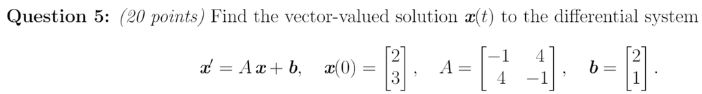

Well we can use the formula from above.

$$ A = \begin{bmatrix} -1 & 4\\4&-1\end{bmatrix} \\ A^{-1} = \frac{1}{15} \begin{bmatrix} 1 & 4\\4&1\end{bmatrix} \\ x(t) = e^{\begin{bmatrix} -t & 4t\\4t&-t\end{bmatrix}}\left(\begin{pmatrix} 2 \\ 3 \end{pmatrix} + \frac{1}{15} \begin{bmatrix} 1 & 4\\4&1\end{bmatrix}\begin{pmatrix} 2 \\ 1 \end{pmatrix} \right)-\frac{1}{15} \begin{bmatrix} 1 & 4\\4&1\end{bmatrix}\begin{pmatrix} 2 \\ 1 \end{pmatrix} \\ = \begin{pmatrix} e^{-t} & e^{4t} \\ e^{4t} & e^{-t} \end{pmatrix} \left(\begin{pmatrix} 2 \\ 3 \end{pmatrix} + \frac{1}{15} \begin{pmatrix} 6 \\ 9 \end{pmatrix} \right) - \frac{1}{15} \begin{pmatrix} 6 \\ 9 \end{pmatrix} \\ =\begin{pmatrix} e^{-t} & e^{4t} \\ e^{4t} & e^{-t} \end{pmatrix} \begin{pmatrix} 2.4 \\ 3.6 \end{pmatrix} - \begin{pmatrix} 0.4 \\ 0.6 \end{pmatrix} \\ x(t)=\begin{pmatrix} 2.4e^{-t}+3.6e^{4t}-0.4 \\ 2.4e^{4t}+3.6e^{-t}-0.6 \end{pmatrix} $$